# Analysis of IATTC Dataset - Tuna and Billfish EPO longline catch and effort

The case for Albacore, Yellowfin, and Black Marlin in the Pacific

Austin Wells

University of Miami

# Introduction

This project attempts to analyze tuna and billfish Eastern Pacific Ocean (EPO) longline catch data from the Inter-American Tropical Tuna Commission (IATTC).

Data contained was provided by Members and Cooperating Non-Members, on catch of tuna and billfishes in number of individuals and metric tons, and number of hooks, by year, month, flag, and 5°x5° latitude/longitude, by industrial longline vessels.

# Objectives

This project aims to analyze trends for the following fish types (Species): Albacore, Yellowfin, and Black Marlin.

- Generate 2024 catch summaries aggregated by species and country, including:
  - Monthly Average Catch Weight.
  - Average Number of Fish Caught.
- Visualize:
  - The overall amount of catch caught in 2024 in the Eastern Pacific Ocean.

# Data Source

## Data comes from:

- Inter-American Tropical Tuna Commission (IATTC) - Public Domain for Data Download
  - Published: September 2025
  - Click [link](https://www.iattc.org/en-US/Data/Public-domain)
- Data Sets/ Files:
  - PublicLLTunaBillfishMt.csv
  - PublicLLTunaBillfishNum.csv

## Variables:

- Date - Date - Year-Month; XXXX-XX-XX
- Flag - Character - Renamed to ‘Country’; Abbreviation of country name
- LatC5 - Numeric - Latitude
- LonC5 - Numeric - Longitude
- [Spp]mt - Numeric - Weight of indicated species type (metric ton)
- [Spp]n - Numeric - Amount of individual fish caught (count)
- Species - Character - Fish Type: ALB = Albacore, YFT = Yellowfin, BLM = Black marlin
- Flag Codes Standard ISO-3166 codes used by the IATTC in its documents and publications. For further information on those codes, see https://www.iattc.org/en-US/Data/Reference-codes

# Data Processing

## Building Data for Use

Raw data sets were transformed doing the following:

1. Create single column called ‘date’ (XXXX-XX-XX). Combining the Year and Month.
2. Filter data to only represent fish of choice: (Albacore = ALB, Yellowfin = YFT, & Black Marlin = BLM)
3. Filter data to only provide year 2024.
4. Framing data to provide the following by species:
   1. Monthly Average Weight (mt)
   2. Monthly Average Catch (num)

# Results/ Findings

## Tables & Figures

### Monthly Average Catch Weight in 2024

#### Figure A.

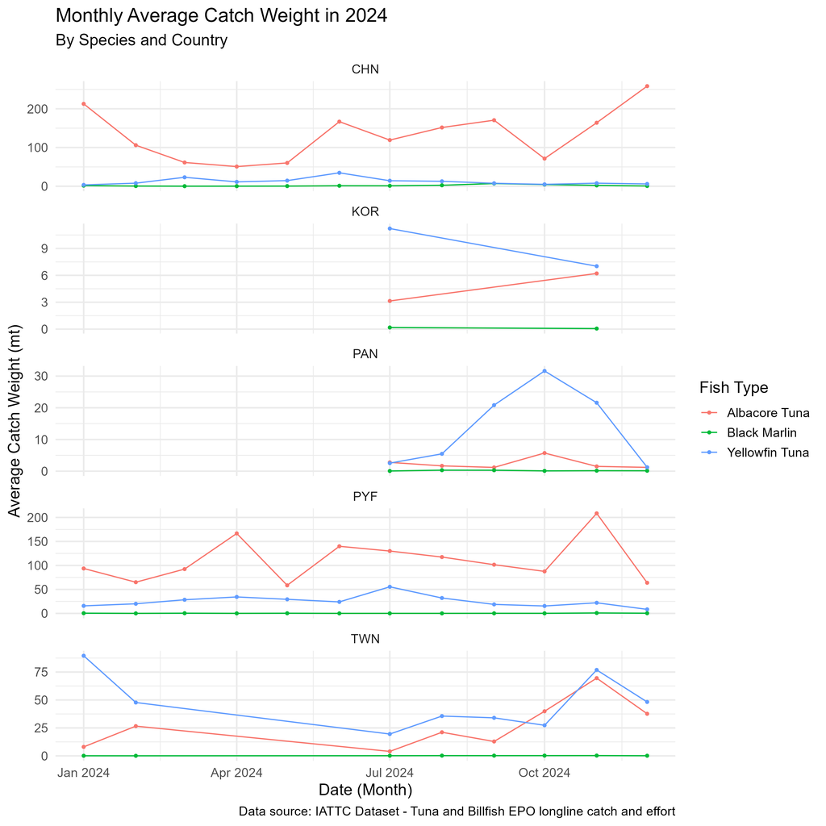

Figure A.

**Figure A.** displays the a timeline of the monthly catch weight reported by each country in the year 2024. Fish type (species) is indicated by the color lines, demonstrating the trends over time for the provided data points. Black marlin tended to have a lower average catch weight when compared to Albacore tuna and Yellowfin tuna. Overall there seems to be some increase in monthly average catch weight for Albacore Tuna and Yellowfin Tuna during the autumn season followed by a decrease a the end of winter.

## Tables & Figures

### Average Amount of Fish Caught in 2024

#### Figure B.

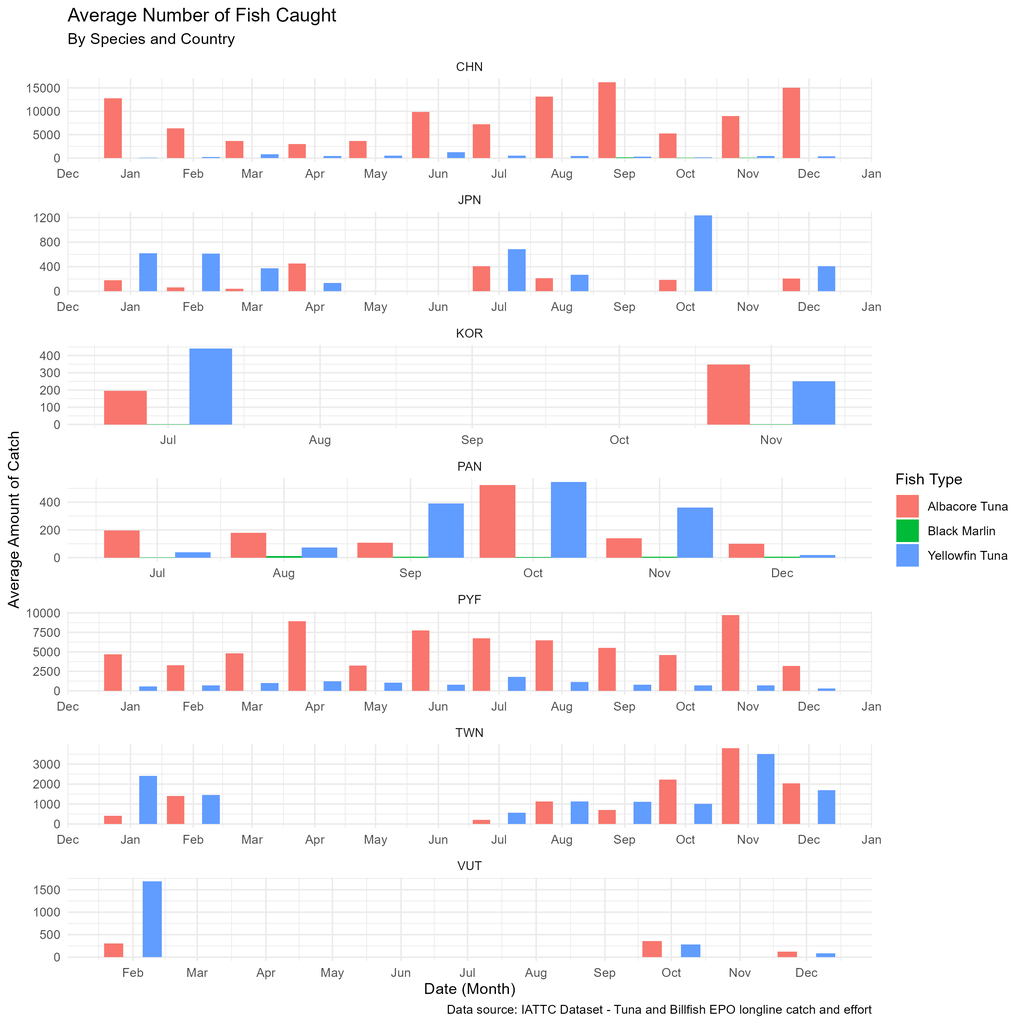

Figure B.

**Figure B.** displays the average amount of fish caught per month in the year 2024. Fish type (species) is indicated by the color bars. Albacore Tuna looks to be the dominating type of catch followed by Yellofin Tuna, then Black Marlin. Across countries, average catch amount was its highest during late summer and fall.

## Map Visualizations

Visualizations below display a heat map of overall catch amount for each fish type in the East Pacific Ocean for the year 2024. Higher catch amount is represented by lighter color shade while lower catch amount is a darker color shade.

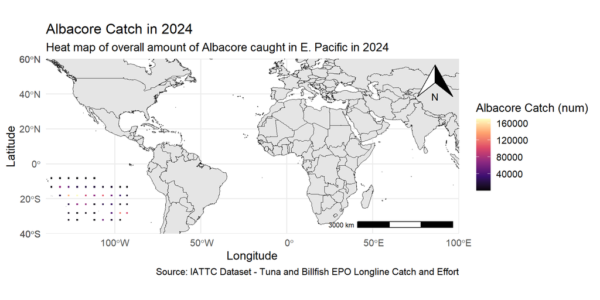

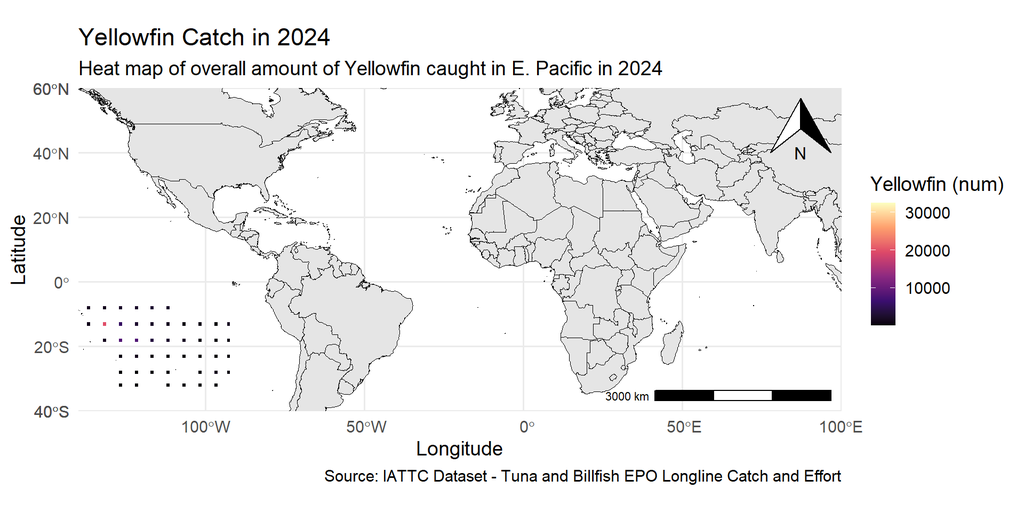

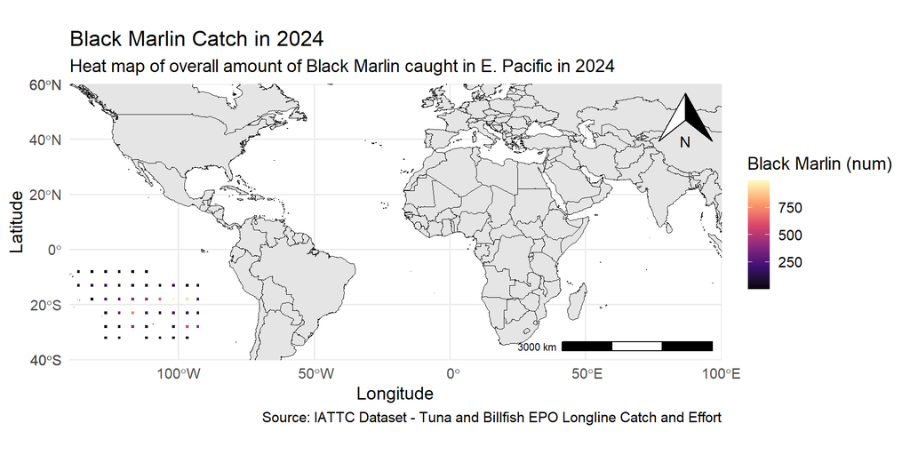

# References

This presentation contains data from:

*The Inter-American Tropical Tuna Commission (IATTC) - Public Domain for Data Download (September 2025). https://www.iattc.org/en-US/Data/Public-domain

quarto publish quarto-pub final_presentation.qmd